# 处置效应因子测试

陶阿明

2016/11/29

## 一、因子综述

### (一)因子简介

处置效应因子是来源于学术界的一个因子，因子的构造稍微有点复杂，效果还不错。处置效应因子的构建步骤如下：
$$Gain_t=\sum_{n=1}^\infty w_{t-n}gain_{t-n}$$

$$gain_{t-n}=\frac{P_t-P_{t-n}}{P_t}*1_{\{P_{t-n}\leq P_t\}}$$

$$w_{t-n}=\frac{1}{k}V_{t-n}\prod_{i=1}^{n-1}(1-V_{t-n+i})$$

$$Loss_t=\sum_{n=1}^\infty w_{t-n}loss_{t-n}$$

$$loss_{t-n}=\frac{P_t-P_{t-n}}{P_t}*1_{\{P_{t-n}> P_t\}}$$

其中$P_t$是股票的最新后复权价格,$P_{t-n}$是股票$n$日前的后复权价格,$1_{\{P_{t-n}\leq P_t\}}$是示性函数，当$P_{t-n}$小于等于$P_t$时，该函数值为1反之为0。

$V_{t-n}$是股票$n$日前当天的换手率,$w_{t-n}$是一个权重，含义是该股票在$t-n$日被买入，然后一直持有到现在的概率，计算的窗口期为$21*3=63$个交易日。

最终的因子值是$Gain_t+Loss_t$。

### (二)因子效果展示

因子IC序列如下图所示：

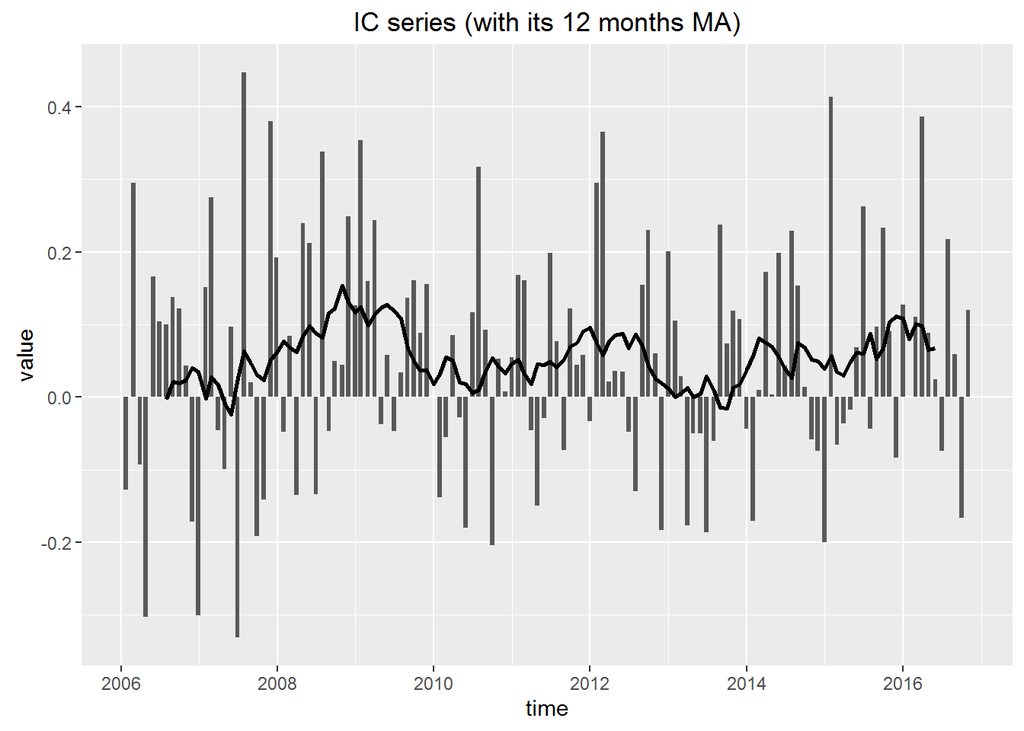

因子分组的年化收益率如下图所示：

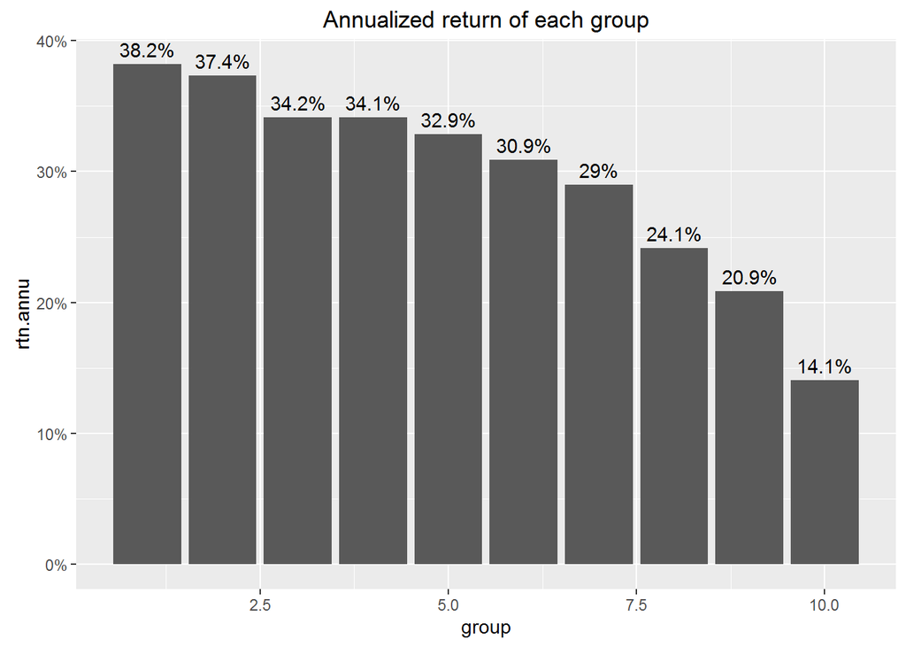

因子多空收益如下图所示：

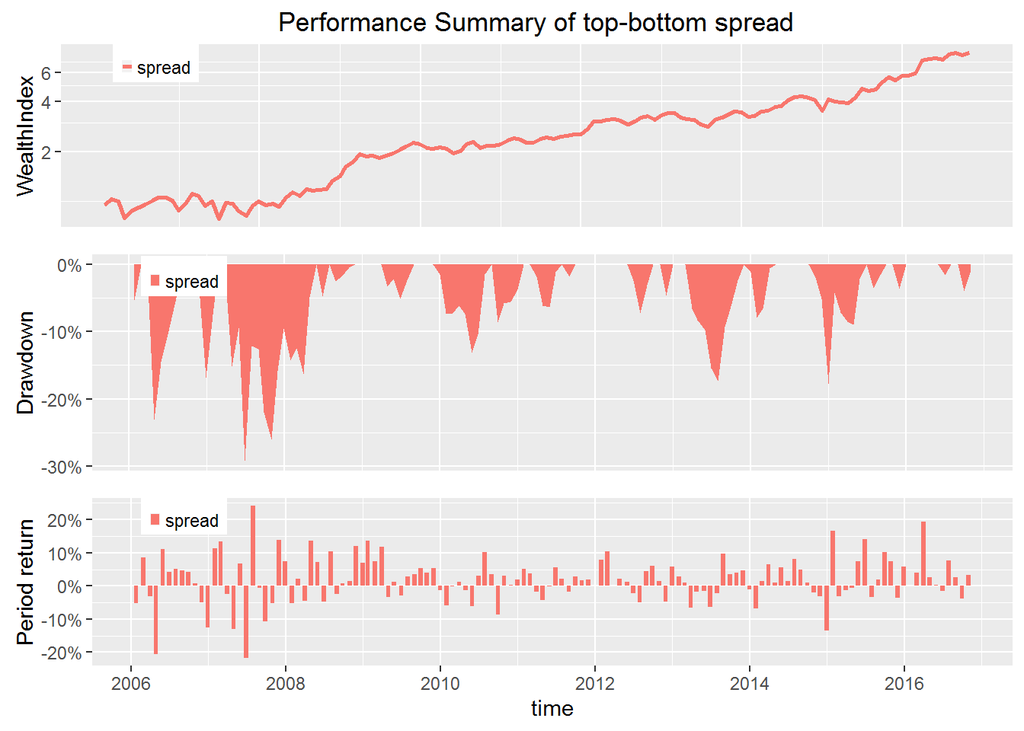

### (三)纯因子组合

上述因子IC、因子分组、因子多空组合不能剥离行业、市值等风格特征。下面构建的纯因子组合是剔除了市值、行业、估值等风险特征的纯因子组合，更能有效的反映因子的alpha性。

纯因子组合收益率如下图所示：

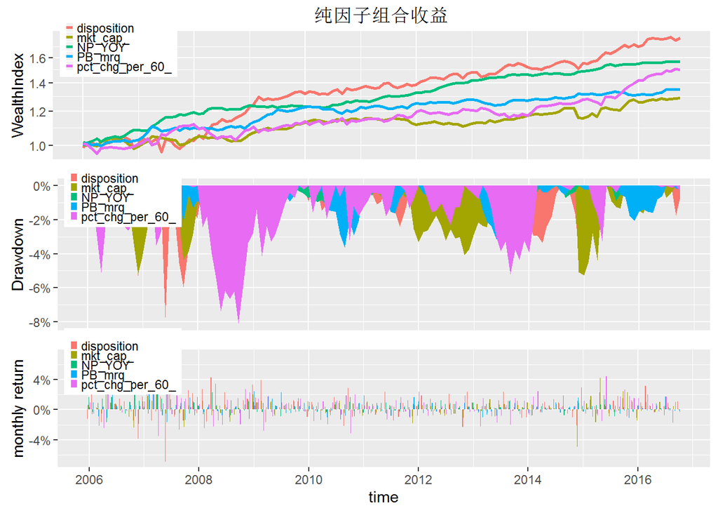

纯因子组合收益率统计如下表：

|  | disposition | mkt_cap_ | NP_YOY | PB_mrq_ | pct_chg_per_60_ |
| --- | --- | --- | --- | --- | --- |
| 2005-12-30 ~ 2005-12-30 | -1.3% | 0.6% | 1.7% | 0.3% | 1% |
| 2006-01-25 ~ 2006-12-29 | 2% | -1.2% | 7% | 2.6% | -0.6% |
| 2007-01-31 ~ 2007-12-28 | 1.8% | 4.3% | 9.7% | 6.7% | 11.5% |
| 2008-01-31 ~ 2008-12-31 | 19.7% | 2.4% | 4% | 2.2% | -2.8% |
| 2009-01-23 ~ 2009-12-31 | 7.6% | 6.6% | -0.7% | 9.4% | 4.5% |
| 2010-01-29 ~ 2010-12-31 | 2.9% | 1% | 2.9% | 0.1% | 0.6% |
| 2011-01-31 ~ 2011-12-30 | 1.8% | -2.2% | 4.7% | 2.2% | 4.6% |
| 2012-01-31 ~ 2012-12-31 | 6.9% | 0.4% | 6.8% | 2% | 1% |
| 2013-01-31 ~ 2013-12-31 | 2.9% | 4.5% | 3.3% | -0.7% | -2.7% |
| 2014-01-30 ~ 2014-12-31 | 2.2% | -1.4% | 1.8% | 3.5% | 8.9% |
| 2015-01-30 ~ 2015-12-31 | 9.2% | 9% | 4.1% | -0.1% | 10.7% |
| 2016-01-29 ~ 2016-09-30 | 4.8% | 2.1% | 1% | 2.6% | 6% |
| Cumulative Return | 78% | 28.9% | 56.8% | 34.9% | 50.1% |
| Annualized Return | 5.5% | 2.4% | 4.2% | 2.8% | 3.8% |
| Annualized StdDev | 5.9% | 3.8% | 2.3% | 3% | 4.8% |
| Annualized Sharpe(Rf=0%) | 92.7% | 63.1% | 186% | 93.9% | 78.8% |
| Worst Drawdown | 7.7% | 5.3% | 1.7% | 3.6% | 8.1% |

## 二、核心指数回测

上面的测试都是全市场测试，下面将在沪深300和中证500里面分别测试因子的效果。

### (一)沪深300

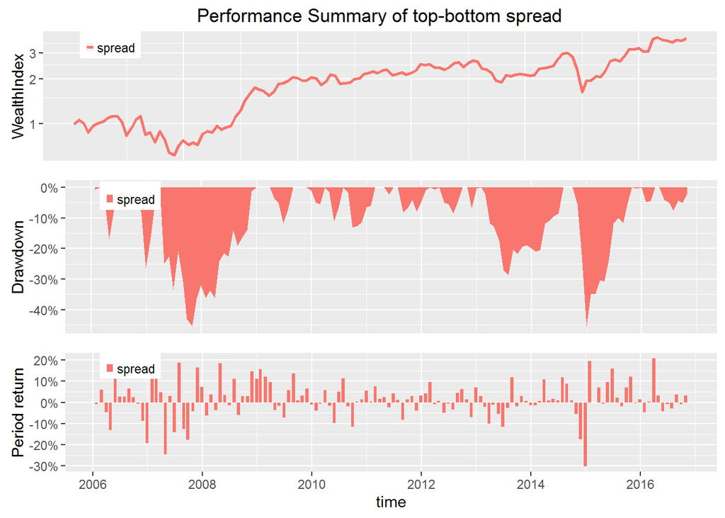

### (二)中证500

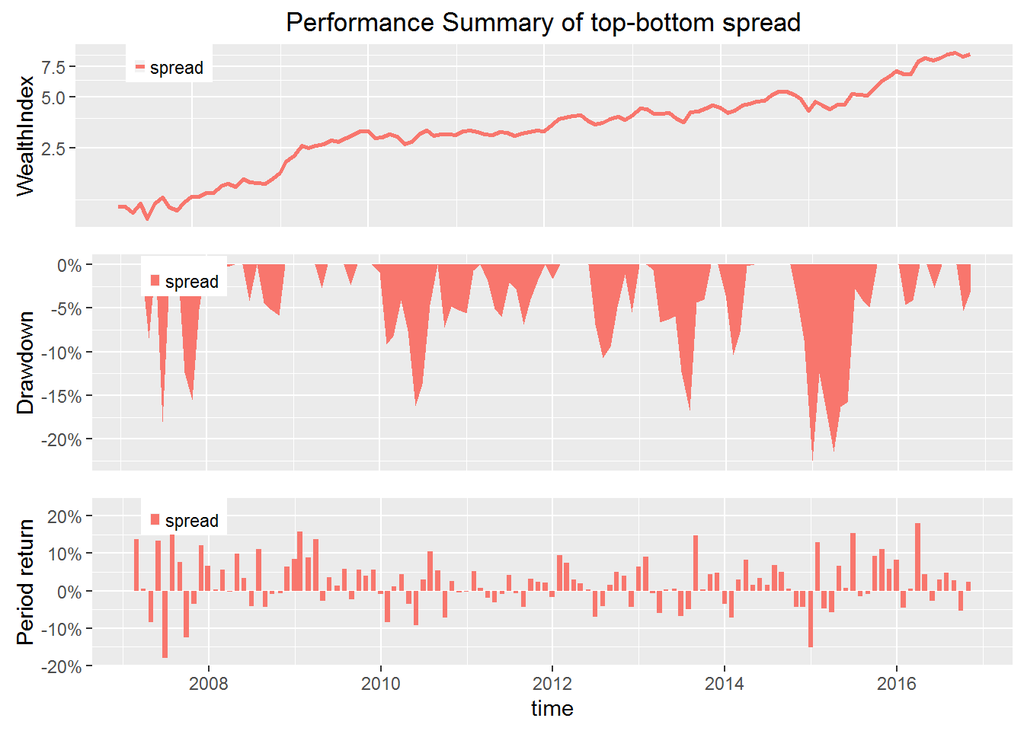

### (三)指数统计

两个指数中因子的IC统计和因子的多空组合收益率如下表所示

|  | EI000300 | EI000905 |
| --- | --- | --- |
| IC均值 | 0.044 | 0.066 |
| IC标准差 | 0.202 | 0.160 |
| ICIR | 0.218 | 0.414 |
| IC胜率 | 0.592 | 0.667 |
| 多空组合年化收益 | 0.130 | 0.250 |
| 多空组合年化波动率 | 0.293 | 0.234 |
| 多空组合年化夏普 | 0.444 | 1.066 |
| 多空组合最大回撤 | 0.455 | 0.225 |

## 三、大类行业回测

### (一)大周期

大周期覆盖农林牧渔、采掘、化工、钢铁、有色金属。

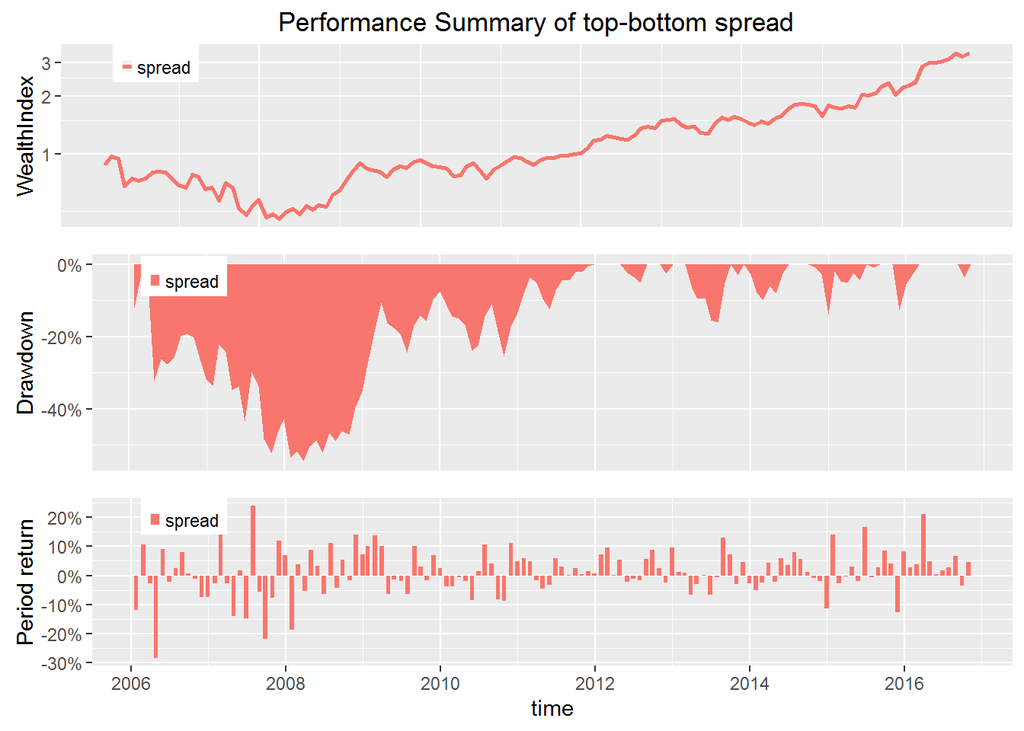

### (二)金融地产

金融地产组覆盖银行、非银、房地产。

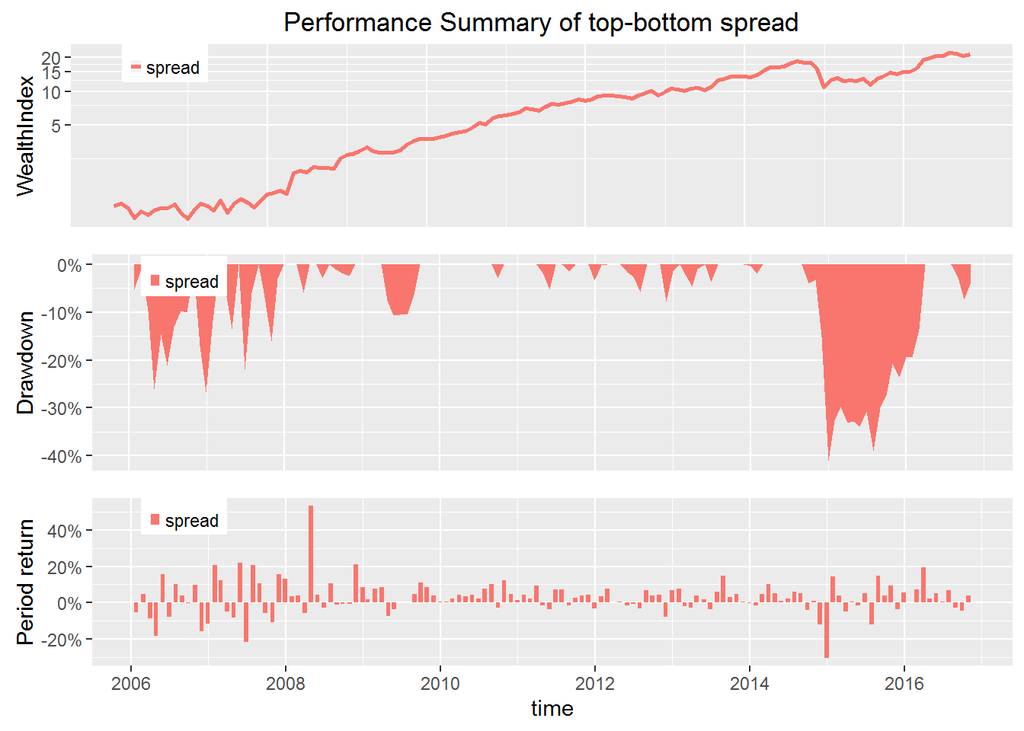

### (三)TMT

TMT覆盖电子、计算机、传媒、通信。

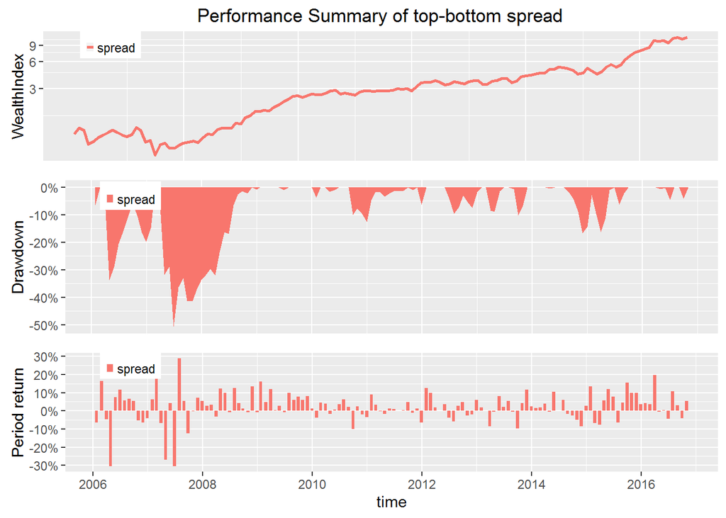

### (四)大消费

大消费覆盖汽车、家用电器、食品饮料、纺织服装、休闲服务、医药生物、商业贸易。

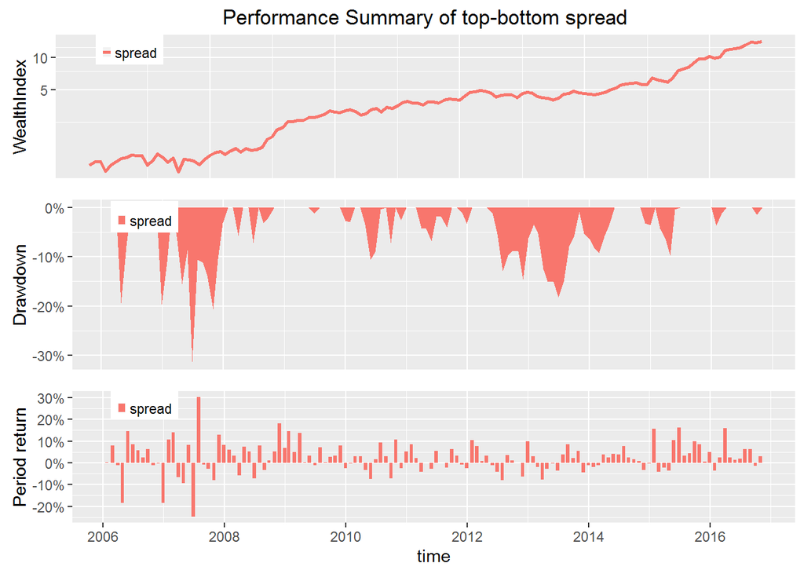

### (五)制造组

制造组覆盖轻工制造、建筑材料、建筑建材、电气设备、机械设备、国防军工。

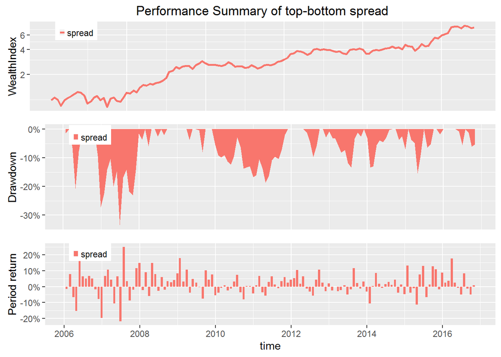

### (六)其他

其他覆盖公共事业、交通运输、综合。

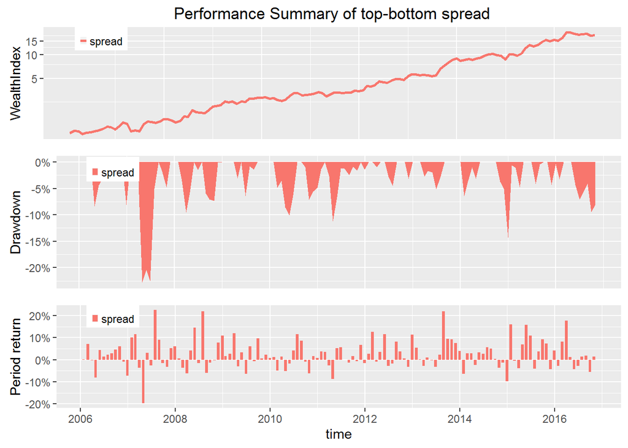

### (七)行业统计

大类行业中因子的IC统计和因子的多空组合收益率如下表所示

|  | 周期 | 金融地产 | TMT | 消费 | 制造 | 其他 |
| --- | --- | --- | --- | --- | --- | --- |
| IC均值 | 0.044 | 0.079 | 0.063 | 0.066 | 0.054 | 0.069 |
| IC标准差 | 0.177 | 0.174 | 0.177 | 0.165 | 0.163 | 0.173 |
| ICIR | 0.247 | 0.455 | 0.359 | 0.399 | 0.334 | 0.401 |
| IC胜率 | 0.615 | 0.646 | 0.662 | 0.662 | 0.585 | 0.646 |
| 多空组合年化收益 | 0.120 | 0.326 | 0.249 | 0.277 | 0.202 | 0.304 |
| 多空组合年化波动率 | 0.272 | 0.321 | 0.285 | 0.248 | 0.248 | 0.228 |
| 多空组合年化夏普 | 0.439 | 1.017 | 0.873 | 1.118 | 0.815 | 1.331 |
| 多空组合最大回撤 | 0.543 | 0.411 | 0.506 | 0.313 | 0.334 | 0.228 |